# Session 6

Validation of model assumptions

Matt Denwood

2022-06-09

## Key model assumptions

The following model assumptions are critical:

- Consistent sensitivity and specificity across populations
- Populations are not based on a diagnostic test that is correlated with those used in the model
- Any missing data is missing completely at random (MCAR) or missing at random (MAR)
- Any between-test correlation structure is described (for >=3 tests)

## Types of missingness

MCAR: Missing completely at random

- There is absolutely no pattern to the missingness
- This is the best kind

MAR: Missing at random

- There is a pattern to the missingness but we know what it is
- This is usually possible to deal with but needs some consideration

MNAR: Missing not at random

- There is an unknown (or unrecorded) pattern to the missingness
- It is therefore possible that the prevalence is confounded with missingness

## Missingness and template Hui-Walter

We can simulate MCAR data as follows:

```r
set.seed(2021-06-30)
# Parameter values to simulate:
N <- 1000
sensitivity <- c(0.8, 0.9, 0.95)
specificity <- c(0.95, 0.99, 0.95)

Populations <- 2
prevalence <- c(0.25,0.5)

data <- tibble(Population = sample(seq_len(Populations), N, replace=TRUE)) %>%
  mutate(Status = rbinom(N, 1, prevalence[Population])) %>%
  mutate(Test1 = rbinom(N, 1, sensitivity[1]*Status + (1-specificity[1])*(1-Status))) %>%
  mutate(Test2 = rbinom(N, 1, sensitivity[2]*Status + (1-specificity[2])*(1-Status))) %>%
  mutate(Test3 = rbinom(N, 1, sensitivity[3]*Status + (1-specificity[3])*(1-Status))) %>%
  select(-Status)
```

Now introduce missingness in all 3 tests:

```r
missingness <- c(0.1, 0.2, 0.3)
data <- data %>%
  mutate(Test1 = case_when(
    rbinom(n(), 1, missingness[1]) == 1L ~ NA_integer_,
    TRUE ~ Test1
  )) %>%
  mutate(Test2 = case_when(
    rbinom(n(), 1, missingness[2]) == 1L ~ NA_integer_,
    TRUE ~ Test2
  )) %>%
  mutate(Test3 = case_when(
    rbinom(n(), 1, missingness[3]) == 1L ~ NA_integer_,
    TRUE ~ Test3
  ))
```

```r
data %>% count(Missing1 = is.na(Test1), Missing2 = is.na(Test2), Missing3 = is.na(Test3))
## # A tibble: 8 × 4
##   Missing1 Missing2 Missing3     n
##   <lgl>    <lgl>    <lgl>    <int>
## 1 FALSE    FALSE    FALSE      513
## 2 FALSE    FALSE    TRUE       210
## 3 FALSE    TRUE     FALSE      126
## 4 FALSE    TRUE     TRUE        56
## 5 TRUE     FALSE    FALSE       54
## 6 TRUE     FALSE    TRUE        20
## 7 TRUE     TRUE     FALSE       14
## 8 TRUE     TRUE     TRUE         7
```

We can simply feed this data to `template_huiwalter`:

```r
template_huiwalter(data, outfile="huiwalter_MAR.txt")
## The model and data have been written to huiwalter_MAR.txt in the current working directory
## You should check and alter priors before running the model
```

What does that look like…?

```
model{

    ## Observation layer:

    # Complete observations (N=513):
    for(p in 1:Populations){
        Tally_RRR[1:8,p] ~ dmulti(prob_RRR[1:8,p], N_RRR[p])

        prob_RRR[1:8,p] <- se_prob[1:8,p] + sp_prob[1:8,p]
    }
```

```
    # Partial observations (Test1: Recorded, Test2: Missing, Test3: Missing; N=56):
    for(p in 1:Populations){
        Tally_RMM[1:2,p] ~ dmulti(prob_RMM[1:2,p], N_RMM[p])

        prob_RMM[1:2,p] <-  se_prob[c(1,2),p] + sp_prob[c(1,2),p] +
                            se_prob[c(3,4),p] + sp_prob[c(3,4),p] +
                            se_prob[c(5,6),p] + sp_prob[c(5,6),p] +
                            se_prob[c(7,8),p] + sp_prob[c(7,8),p]
    }

    # Partial observations (Test1: Recorded, Test2: Recorded, Test3: Missing; N=210):
    for(p in 1:Populations){
        Tally_RRM[1:4,p] ~ dmulti(prob_RRM[1:4,p], N_RRM[p])

        prob_RRM[1:4,p] <-  se_prob[c(1,2,3,4),p] + sp_prob[c(1,2,3,4),p] +
                            se_prob[c(5,6,7,8),p] + sp_prob[c(5,6,7,8),p]
    }
```

```
    # Partial observations (Test1: Missing, Test2: Recorded, Test3: Recorded; N=54):
    for(p in 1:Populations){
        Tally_MRR[1:4,p] ~ dmulti(prob_MRR[1:4,p], N_MRR[p])

        prob_MRR[1:4,p] <-  se_prob[c(1,3,5,7),p] + sp_prob[c(1,3,5,7),p] +
                            se_prob[c(2,4,6,8),p] + sp_prob[c(2,4,6,8),p]
    }

    # Partial observations (Test1: Missing, Test2: Recorded, Test3: Missing; N=20):
    for(p in 1:Populations){
        Tally_MRM[1:2,p] ~ dmulti(prob_MRM[1:2,p], N_MRM[p])

        prob_MRM[1:2,p] <-  se_prob[c(1,3),p] + sp_prob[c(1,3),p] +
                            se_prob[c(2,4),p] + sp_prob[c(2,4),p] +
                            se_prob[c(5,7),p] + sp_prob[c(5,7),p] +
                            se_prob[c(6,8),p] + sp_prob[c(6,8),p]
    }
```

```
    # Partial observations (Test1: Missing, Test2: Missing, Test3: Recorded; N=14):
    for(p in 1:Populations){
        Tally_MMR[1:2,p] ~ dmulti(prob_MMR[1:2,p], N_MMR[p])

        prob_MMR[1:2,p] <-  se_prob[c(1,5),p] + sp_prob[c(1,5),p] +
                            se_prob[c(2,6),p] + sp_prob[c(2,6),p] +
                            se_prob[c(3,7),p] + sp_prob[c(3,7),p] +
                            se_prob[c(4,8),p] + sp_prob[c(4,8),p]
    }
```

NB: `MMM` combinations have been removed!

```
    ## Observation probabilities:

    for(p in 1:Populations){

        # Probability of observing Test1- Test2- Test3- from a true positive::
        se_prob[1,p] <- prev[p] * ((1-se[1])*(1-se[2])*(1-se[3]) +covse12 +covse13 +covse23)
        # Probability of observing Test1- Test2- Test3- from a true negative::
        sp_prob[1,p] <- (1-prev[p]) * (sp[1]*sp[2]*sp[3] +covsp12 +covsp13 +covsp23)

        # Probability of observing Test1+ Test2- Test3- from a true positive::
        se_prob[2,p] <- prev[p] * (se[1]*(1-se[2])*(1-se[3]) -covse12 -covse13 +covse23)
        # Probability of observing Test1+ Test2- Test3- from a true negative::
        sp_prob[2,p] <- (1-prev[p]) * ((1-sp[1])*sp[2]*sp[3] -covsp12 -covsp13 +covsp23)

        # Probability of observing Test1- Test2+ Test3- from a true positive::
        se_prob[3,p] <- prev[p] * ((1-se[1])*se[2]*(1-se[3]) -covse12 +covse13 -covse23)
        # Probability of observing Test1- Test2+ Test3- from a true negative::
        sp_prob[3,p] <- (1-prev[p]) * (sp[1]*(1-sp[2])*sp[3] -covsp12 +covsp13 -covsp23)

        # Probability of observing Test1+ Test2+ Test3- from a true positive::
        se_prob[4,p] <- prev[p] * (se[1]*se[2]*(1-se[3]) +covse12 -covse13 -covse23)
        # Probability of observing Test1+ Test2+ Test3- from a true negative::
        sp_prob[4,p] <- (1-prev[p]) * ((1-sp[1])*(1-sp[2])*sp[3] +covsp12 -covsp13 -covsp23)

        # Probability of observing Test1- Test2- Test3+ from a true positive::
        se_prob[5,p] <- prev[p] * ((1-se[1])*(1-se[2])*se[3] +covse12 -covse13 -covse23)
        # Probability of observing Test1- Test2- Test3+ from a true negative::
        sp_prob[5,p] <- (1-prev[p]) * (sp[1]*sp[2]*(1-sp[3]) +covsp12 -covsp13 -covsp23)

        # Probability of observing Test1+ Test2- Test3+ from a true positive::
        se_prob[6,p] <- prev[p] * (se[1]*(1-se[2])*se[3] -covse12 +covse13 -covse23)
        # Probability of observing Test1+ Test2- Test3+ from a true negative::
        sp_prob[6,p] <- (1-prev[p]) * ((1-sp[1])*sp[2]*(1-sp[3]) -covsp12 +covsp13 -covsp23)

        # Probability of observing Test1- Test2+ Test3+ from a true positive::
        se_prob[7,p] <- prev[p] * ((1-se[1])*se[2]*se[3] -covse12 -covse13 +covse23)
        # Probability of observing Test1- Test2+ Test3+ from a true negative::
        sp_prob[7,p] <- (1-prev[p]) * (sp[1]*(1-sp[2])*(1-sp[3]) -covsp12 -covsp13 +covsp23)

        # Probability of observing Test1+ Test2+ Test3+ from a true positive::
        se_prob[8,p] <- prev[p] * (se[1]*se[2]*se[3] +covse12 +covse13 +covse23)
        # Probability of observing Test1+ Test2+ Test3+ from a true negative::
        sp_prob[8,p] <- (1-prev[p]) * ((1-sp[1])*(1-sp[2])*(1-sp[3]) +covsp12 +covsp13 +covsp23)

    }
```

```
# "covsp13" <- 0
# "covsp23" <- 0
}
inits{
"se" <- c(0.99, 0.5, 0.99)
"sp" <- c(0.75, 0.99, 0.75)
"prev" <- c(0.95, 0.05)
# "covse12" <- 0
# "covse13" <- 0
# "covse23" <- 0
# "covsp12" <- 0
# "covsp13" <- 0
# "covsp23" <- 0
}

## Data:
data{
"Populations" <- 2
```

## How to form populations

Clearly valid strategies:

- Temporal and/or spatial separation (e.g. farms)
- Experimental separation (different blocks of a trial)
- Separation based on testing other individuals within the same cohort (e.g. historical data)

…

Clearly invalid strategies:

- Grouping based on the results of a diagnostic test being evaluated in the same individuals

…

Potentially OK but sometimes risky strategies:

- Grouping by age, breed or sex (is sensitivity/specificity consistent?)
- Grouping based on the results of a diagnostic test not under consideration in the same individuals (is it correlated with one of the tests being evaluated?)

## Consistent sensitivity and specificity

Strategies to verify this:

- Eliminate one test at a time and re-run the model (if >=3 tests)
- Eliminate one population at a time and re-run the model (if >=3 populations, or >=2 populations with strong priors)
- Allow sensitivity or specificity to differ between populations (requires a lot of data) - see session 7

## Making your data missing

If we have >2 populations *and* >2 tests then we can eliminate one combination at a time!

- This is a very useful form of cross-validation

Estimating the full model:

```r
template_huiwalter(data, "model_full.txt")
results_full <- run.jags("model_full.txt")
## Loading required namespace: rjags
# Check convergence etc:
# plot(results_full)
# results_full

summary_full <- summary(results_full, vars="^s") %>%
  as.data.frame() %>%
  rownames_to_column("Parameter") %>%
  mutate(Model = "Full") %>%
  select(Model, Parameter, Median, Lower95, Upper95)
```

How can we make a specific population missing?

```r
crossval_data <- data %>%
  filter(Population != 1)

template_huiwalter(crossval_data, "model_mp1.txt")
results_crossval <- run.jags("model_mp1.txt")
summary_crossval <- summary(results_crossval, vars="^s") %>%
  as.data.frame() %>%
  rownames_to_column("Parameter") %>%
  mutate(Model = "MP1") %>%
  select(Model, Parameter, Median, Lower95, Upper95) %>%
  bind_rows(summary_full) %>%
  arrange(Parameter, Model)
```

```r
summary_crossval
##    Model Parameter    Median   Lower95   Upper95
## 1   Full     se[1] 0.8321134 0.7836497 0.8760596
## 2    MP1     se[1] 0.8246393 0.7649763 0.8799912
## 3   Full     se[2] 0.9030361 0.8569913 0.9435000
## 4    MP1     se[2] 0.8930158 0.8373477 0.9440217
## 5   Full     se[3] 0.9427096 0.9073215 0.9747376
## 6    MP1     se[3] 0.9420718 0.8964427 0.9789088
## 7   Full     sp[1] 0.9599940 0.9382361 0.9793268
## 8    MP1     sp[1] 0.9713333 0.9388618 0.9977420
## 9   Full     sp[2] 0.9890339 0.9742596 0.9999779
## 10   MP1     sp[2] 0.9770030 0.9487166 0.9999120
## 11  Full     sp[3] 0.9485972 0.9217073 0.9736218
## 12   MP1     sp[3] 0.9458404 0.8971288 0.9861643
```

How many combinations of test missingness and population do we have?

```r
all_combinations <- data %>%
  pivot_longer(-Population, names_to = "Test", values_to = "Result") %>%
  filter(!is.na(Result)) %>%
  count(Population, Test) %>%
  print()
## # A tibble: 6 × 3
##   Population Test      n
##        <int> <chr> <int>
## 1          1 Test1   420
## 2          1 Test2   370
## 3          1 Test3   331
## 4          2 Test1   485
## 5          2 Test2   427
## 6          2 Test3   376
```

How can we make a specific combination of test and population missing?

```r
all_results <- vector('list', length=nrow(all_combinations))
all_summary <- vector('list', length=nrow(all_combinations))

crossval_data <- data %>%
  mutate(Test1 = case_when(
    Population == 1 ~ NA_integer_,
    TRUE ~ Test1
  ))

template_huiwalter(crossval_data, "model_mc11.txt")
all_results[[1]] <- run.jags("model_mc11.txt")
# Assess convergence and sample size!
all_summary[[1]] <- summary(all_results[[1]], vars="^s") %>%
  as.data.frame() %>%
  rownames_to_column("Parameter") %>%
  mutate(Model = "MC11") %>%
  select(Model, Parameter, Median, Lower95, Upper95)
```

```r
crossval_data <- data %>%
  mutate(Test2 = case_when(
    Population == 1 ~ NA_integer_,
    TRUE ~ Test2
  ))

template_huiwalter(crossval_data, "model_mc12.txt")
all_results[[2]] <- run.jags("model_mc12.txt")
# Assess convergence and sample size!
all_summary[[2]] <- summary(all_results[[2]], vars="^s") %>%
  as.data.frame() %>%
  rownames_to_column("Parameter") %>%
  mutate(Model = "MC12") %>%
  select(Model, Parameter, Median, Lower95, Upper95)
```

etc…!

Are there any substantial disagreements:

```r
bind_rows(list(summary_full, all_summary)) %>% arrange(Parameter, Model)
##    Model Parameter    Median   Lower95   Upper95
## 1   Full     se[1] 0.8321134 0.7836497 0.8760596
## 2   MC11     se[1] 0.8202861 0.7618229 0.8749764
## 3   MC12     se[1] 0.8268109 0.7693934 0.8802771
## 4   Full     se[2] 0.9030361 0.8569913 0.9435000
## 5   MC11     se[2] 0.8940017 0.8391566 0.9450881
## 6   MC12     se[2] 0.8947212 0.8396298 0.9445758
## 7   Full     se[3] 0.9427096 0.9073215 0.9747376
## 8   MC11     se[3] 0.9452830 0.9065026 0.9803945
## 9   MC12     se[3] 0.9392076 0.8920058 0.9778604
## 10  Full     sp[1] 0.9599940 0.9382361 0.9793268
## 11  MC11     sp[1] 0.9709245 0.9378814 0.9967919
## 12  MC12     sp[1] 0.9649222 0.9385057 0.9896540
## 13  Full     sp[2] 0.9890339 0.9742596 0.9999779
## 14  MC11     sp[2] 0.9852817 0.9672249 0.9999574
## 15  MC12     sp[2] 0.9774938 0.9485199 0.9999166
## 16  Full     sp[3] 0.9485972 0.9217073 0.9736218
## 17  MC11     sp[3] 0.9502273 0.9164090 0.9824996
## 18  MC12     sp[3] 0.9527636 0.9195414 0.9871938
```

# Practical session 6

## Exercise 1

For this exercise you will need the 3-test, 3-population dataset provided as “anthrax.Rdata” under day 3. Here is what the data look like:

```
##         Population        PMB           AzureB          qPCR
##  Population_A:136   Negative:556   Negative:558   Negative:519
##  Population_B:174   Positive:110   Positive:108   Positive:147
##  Population_C:356
```

We have the result of 3 anthrax tests on cattle carcasses from 3 populations:

- PMB (polychrome methylene blue) is a stain used to help detect the capsule of anthrax bacteria on blood smears
- AzureB is a similar stain that is easier to perform in low resource settings
- qPCR is a test for DNA of the anthrax bacteria

All populations consistent of carcasses reported as sudden death events in extensively farmed cattle in 3 different populated areas surrounding the Serengeti national park. The samples from populations A and B consisted of blood smears taken directly from the carcasses, while the samples for population C consisted of blood smears made from blood swabs taken from the carcasses. qPCR resutls were obtain from fragments of blood scraped from the blood smears.

Analyse the data using minimally informative priors for all parameters. Try to identify any potential pairwise correlations between the tests:

- Based on biological reasoning
- Based on empirical evidence

Exclude one population at a time and re-analyse the data. What do you notice about your assumption of constant sensitivity and specificity across populations?

### Solution 1

We can fit this model with no covariance terms relatively easily. Note that the `template_huiwalter` function is quite happy with factors, so there is no need to convert anything to numbers - the function assumes that the reference level of the factor is the negative test:

```r
template_huiwalter(anthrax, "anthrax_model_nocov.txt", covariance=FALSE)
## The model and data have been written to anthrax_model_nocov.txt in the current working directory
## You should check and alter priors before running the model
results_nocov <- run.jags("anthrax_model_nocov.txt")
results_nocov
##
## JAGS model summary statistics from 20000 samples (chains = 2; adapt+burnin = 5000):
##
##          Lower95   Median Upper95     Mean        SD     Mode       MCerr
## se[1]    0.75234  0.83805 0.91284  0.83591   0.04129  0.83819  0.00045946
## se[2]    0.73163  0.81498 0.89072  0.81291  0.041166  0.82199   0.0004401
## se[3]    0.69801  0.77816 0.85731  0.77683  0.040727  0.77829  0.00040636
## sp[1]    0.98165  0.99268       1  0.99181 0.0054014  0.99452 0.000062646
## sp[2]    0.97916  0.99073       1     0.99 0.0059171  0.99222 0.000069132
## sp[3]    0.88276   0.9097 0.93421  0.90927  0.013228  0.91057  0.00012616
## prev[1] 0.047614 0.095071 0.14969 0.097095  0.026539 0.094632   0.0002624
## prev[2] 0.083164  0.13129 0.18454  0.13272  0.026224   0.1301  0.00024183
## prev[3]  0.21249  0.25894 0.31336  0.25968  0.025612  0.25807  0.00026726
## covse12        0        0       0        0         0        0          --
## corse12        0        0       0        0         0        0          --
## covsp12        0        0       0        0         0        0          --
## corsp12        0        0       0        0         0        0          --
## covse13        0        0       0        0         0        0          --
## corse13        0        0       0        0         0        0          --
## covsp13        0        0       0        0         0        0          --
## corsp13        0        0       0        0         0        0          --
## covse23        0        0       0        0         0        0          --
## corse23        0        0       0        0         0        0          --
## covsp23        0        0       0        0         0        0          --
## corsp23        0        0       0        0         0        0          --
##
##         MC%ofSD SSeff      AC.10   psrf
## se[1]       1.1  8076  0.0011018 1.0001
## se[2]       1.1  8749 -0.0040766 1.0001
## se[3]         1 10045  0.0031657      1
## sp[1]       1.2  7434  0.0021895      1
## sp[2]       1.2  7326  0.0074827 1.0001
## sp[3]         1 10993  0.0072037 1.0001
## prev[1]       1 10229 0.00045394 1.0001
## prev[2]     0.9 11759  0.0058783 1.0002
## prev[3]       1  9184  0.0070615 1.0001
## covse12      --    --         --     --
## corse12      --    --         --     --
## covsp12      --    --         --     --
## corsp12      --    --         --     --
## covse13      --    --         --     --
## corse13      --    --         --     --
## covsp13      --    --         --     --
## corsp13      --    --         --     --
## covse23      --    --         --     --
## corse23      --    --         --     --
## covsp23      --    --         --     --
## corsp23      --    --         --     --
##
## Total time taken: 1.3 seconds
```

Fitting the model with all covariance terms is possible but we get low effective sample sizes:

```r
template_huiwalter(anthrax, "anthrax_model_allcov.txt", covariance=TRUE)
## The model and data have been written to anthrax_model_allcov.txt in the current working directory
## You should check and alter priors before running the model
results_allcov <- run.jags("anthrax_model_allcov.txt")
results_allcov
##
## JAGS model summary statistics from 20000 samples (chains = 2; adapt+burnin = 5000):
##
##            Lower95     Median  Upper95       Mean        SD      Mode
## se[1]      0.43077    0.59666  0.78605    0.60319  0.093787   0.58183
## se[2]      0.43073    0.58331  0.77549    0.59057  0.090092   0.56546
## se[3]      0.61739    0.79609  0.95434    0.79241  0.086478   0.79635
## sp[1]      0.93517    0.96746  0.99265    0.96596  0.015012    0.9705
## sp[2]      0.93684     0.9682  0.99355    0.96634   0.01491   0.97168
## sp[3]      0.91274    0.95935  0.99939    0.95733  0.025341   0.97022
## prev[1]   0.074453    0.13512  0.19852    0.13711  0.032269   0.13311
## prev[2]   0.094678    0.15508  0.22309    0.15807  0.033108   0.15209
## prev[3]    0.23064    0.31183  0.42942    0.32116  0.052388   0.30243
## covse12   -0.01068   0.035186 0.082795   0.034853  0.024273  0.034249
## corse12   -0.10536    0.16718  0.40837    0.15689   0.14154   0.16516
## covsp12  0.0023603   0.018175 0.033327   0.018271 0.0079883  0.018163
## corsp12    0.38481    0.73414  0.99992    0.71366    0.1859   0.78197
## covse13  -0.048128 -0.0029936 0.045216 -0.0025257  0.024611 -0.004783
## corse13   -0.94117  -0.041043  0.37839   -0.12629   0.35795  0.062253
## covsp13 -0.0011117   0.007619 0.019194  0.0082192 0.0058903 0.0047223
## corsp13  -0.000101    0.36934  0.94547    0.38391   0.29042   0.33029
## covse23  -0.058901   -0.01538 0.034517  -0.014123   0.02453  -0.01885
## corse23   -0.97691   -0.22798  0.23808   -0.26875   0.36187 -0.065291
## covsp23 -0.0003867   0.010174 0.022732   0.010673 0.0065111 0.0096456
## corsp23   0.090756    0.49575  0.99624    0.49724   0.26967   0.46818
##
##              MCerr MC%ofSD SSeff   AC.10   psrf
## se[1]    0.0057748     6.2   264 0.70616 1.0188
## se[2]    0.0050336     5.6   320 0.67821 1.0174
## se[3]    0.0050022     5.8   299  0.6995 1.0083
## sp[1]   0.00075723       5   393 0.63913 1.0016
## sp[2]    0.0006906     4.6   466 0.60587 1.0002
## sp[3]      0.00138     5.4   337 0.57525 1.0179
## prev[1]  0.0014647     4.5   485 0.49394 1.0127
## prev[2]  0.0014924     4.5   492 0.41289 1.0075
## prev[3]  0.0029255     5.6   321 0.61062 1.0225
## covse12  0.0012466     5.1   379 0.65446 1.0047
## corse12  0.0057476     4.1   606 0.52497 1.0051
## covsp12 0.00058127     7.3   189 0.81273 1.0025
## corsp12  0.0051954     2.8  1280 0.19267 1.0014
## covse13  0.0013573     5.5   329 0.64749 1.0072
## corse13   0.016163     4.5   490  0.5176  1.005
## covsp13 0.00026421     4.5   497 0.59376 1.0018
## corsp13  0.0077214     2.7  1415 0.23843 1.0007
## covse23  0.0012786     5.2   368  0.6625 1.0117
## corse23   0.017524     4.8   426 0.54241  1.012
## covsp23 0.00032672       5   397 0.66008 1.0027
## corsp23  0.0073253     2.7  1355  0.2436      1
##
## Total time taken: 2.1 seconds
```

In order to interpret these results properly we would need to first get more samples e.g.:

```r
results_allcov <- extend.jags(results_allcov, sample=90000, method="parallel")
results_allcov
##
## JAGS model summary statistics from 200000 samples (chains = 2; adapt+burnin = 5000):
##
##             Lower95      Median  Upper95       Mean        SD       Mode
## se[1]       0.41859     0.59206  0.79594    0.60019  0.099523    0.57678
## se[2]       0.41782     0.58106   0.7773    0.58946  0.093967    0.56231
## se[3]        0.6088     0.79058  0.95803    0.78624  0.090554    0.80307
## sp[1]        0.9344     0.96805  0.99392    0.96626  0.015776    0.97093
## sp[2]       0.93656     0.96942  0.99449    0.96738  0.015133     0.9738
## sp[3]       0.91092     0.95964        1    0.95708  0.026218    0.97332
## prev[1]    0.076057     0.13539  0.20771    0.13756  0.033771    0.13085
## prev[2]     0.09488     0.15553  0.22778    0.15898  0.034754    0.15108
## prev[3]     0.23317     0.31375  0.44466    0.32465  0.055499    0.30099
## covse12   -0.013606    0.035982 0.083307   0.035464  0.025622   0.038116
## corse12    -0.12674     0.17229  0.42112    0.15627   0.15506    0.18886
## covsp12 0.000053057    0.017324 0.032539   0.017816 0.0084516   0.016452
## corsp12     0.36987     0.73364  0.99994    0.71111    0.1904    0.78134
## covse13   -0.043164 0.000067754 0.048907 0.00043977  0.024506 -0.0017476
## corse13    -0.94018  0.00065449  0.38109  -0.094787   0.35133   0.092081
## covsp13  -0.0010007   0.0069936 0.018812  0.0077246 0.0056713  0.0037665
## corsp13  0.00016108     0.36041  0.95664    0.37155   0.29646    0.30512
## covse23   -0.055477   -0.012455 0.039121  -0.011401  0.024885  -0.016026
## corse23     -0.9706     -0.1794  0.25732    -0.2412    0.3642  -0.011067
## covsp23  -0.0004705   0.0094547  0.02179  0.0099954 0.0063333  0.0090023
## corsp23    0.070914     0.48798  0.99728    0.48563   0.27967    0.43359
##
##               MCerr MC%ofSD SSeff   AC.10   psrf
## se[1]     0.0022651     2.3  1930 0.73197 1.0018
## se[2]      0.002178     2.3  1861  0.7088 1.0011
## se[3]     0.0020756     2.3  1903 0.73457 1.0007
## sp[1]    0.00030677     1.9  2645 0.66767 1.0002
## sp[2]    0.00030391       2  2479 0.64313      1
## sp[3]    0.00051941       2  2548 0.60055 1.0009
## prev[1]  0.00060596     1.8  3106 0.49675 1.0011
## prev[2]  0.00061217     1.8  3223 0.43533  1.002
## prev[3]   0.0012251     2.2  2052 0.64468 1.0019
## covse12  0.00053551     2.1  2289  0.6918 1.0009
## corse12   0.0028713     1.9  2916  0.5541 1.0011
## covsp12  0.00021243     2.5  1583 0.83006      1
## corsp12   0.0019858       1  9193 0.19341 1.0001
## covse13  0.00049568       2  2444 0.64719  1.001
## corse13   0.0060167     1.7  3410 0.50512 1.0005
## covsp13 0.000093817     1.7  3654 0.58478 1.0002
## corsp13   0.0029882       1  9842 0.22197 1.0007
## covse23  0.00051674     2.1  2319 0.67938 1.0012
## corse23   0.0068538     1.9  2824 0.55475 1.0008
## covsp23  0.00010954     1.7  3343 0.63985      1
## corsp23   0.0028206       1  9832 0.23022      1
##
## Total time taken: 11.2 seconds
```

Now we can see that there is some evidence for positive correlation between tests 1 and 2. This makes biological sense because both are detecting the presence of a specific part of the bacterium (the capsid). The estimates for correlation with test 3 are much closer to zero, except perhaps for the negative covariance in sensitivity between tests 2 and 3.

In this case we probably would want to run the model with only correlation between tests 1 and 2 active. This is what that model would look like:

```
## Auto-generated Hui-Walter model created by runjags version 2.2.2-1 on 2022-06-06

model{

    ## Observation layer:

    # Complete observations (N=666):
    for(p in 1:Populations){
        Tally_RRR[1:8,p] ~ dmulti(prob_RRR[1:8,p], N_RRR[p])

        prob_RRR[1:8,p] <- se_prob[1:8,p] + sp_prob[1:8,p]
    }


    ## Observation probabilities:

    for(p in 1:Populations){

        # Probability of observing PMB- AzureB- qPCR- from a true positive::
        se_prob[1,p] <- prev[p] * ((1-se[1])*(1-se[2])*(1-se[3]) +covse12 +covse13 +covse23)
        # Probability of observing PMB- AzureB- qPCR- from a true negative::
        sp_prob[1,p] <- (1-prev[p]) * (sp[1]*sp[2]*sp[3] +covsp12 +covsp13 +covsp23)

        # Probability of observing PMB+ AzureB- qPCR- from a true positive::
        se_prob[2,p] <- prev[p] * (se[1]*(1-se[2])*(1-se[3]) -covse12 -covse13 +covse23)
        # Probability of observing PMB+ AzureB- qPCR- from a true negative::
        sp_prob[2,p] <- (1-prev[p]) * ((1-sp[1])*sp[2]*sp[3] -covsp12 -covsp13 +covsp23)

        # Probability of observing PMB- AzureB+ qPCR- from a true positive::
        se_prob[3,p] <- prev[p] * ((1-se[1])*se[2]*(1-se[3]) -covse12 +covse13 -covse23)
        # Probability of observing PMB- AzureB+ qPCR- from a true negative::
        sp_prob[3,p] <- (1-prev[p]) * (sp[1]*(1-sp[2])*sp[3] -covsp12 +covsp13 -covsp23)

        # Probability of observing PMB+ AzureB+ qPCR- from a true positive::
        se_prob[4,p] <- prev[p] * (se[1]*se[2]*(1-se[3]) +covse12 -covse13 -covse23)
        # Probability of observing PMB+ AzureB+ qPCR- from a true negative::
        sp_prob[4,p] <- (1-prev[p]) * ((1-sp[1])*(1-sp[2])*sp[3] +covsp12 -covsp13 -covsp23)

        # Probability of observing PMB- AzureB- qPCR+ from a true positive::
        se_prob[5,p] <- prev[p] * ((1-se[1])*(1-se[2])*se[3] +covse12 -covse13 -covse23)
        # Probability of observing PMB- AzureB- qPCR+ from a true negative::
        sp_prob[5,p] <- (1-prev[p]) * (sp[1]*sp[2]*(1-sp[3]) +covsp12 -covsp13 -covsp23)

        # Probability of observing PMB+ AzureB- qPCR+ from a true positive::
        se_prob[6,p] <- prev[p] * (se[1]*(1-se[2])*se[3] -covse12 +covse13 -covse23)
        # Probability of observing PMB+ AzureB- qPCR+ from a true negative::
        sp_prob[6,p] <- (1-prev[p]) * ((1-sp[1])*sp[2]*(1-sp[3]) -covsp12 +covsp13 -covsp23)

        # Probability of observing PMB- AzureB+ qPCR+ from a true positive::
        se_prob[7,p] <- prev[p] * ((1-se[1])*se[2]*se[3] -covse12 -covse13 +covse23)
        # Probability of observing PMB- AzureB+ qPCR+ from a true negative::
        sp_prob[7,p] <- (1-prev[p]) * (sp[1]*(1-sp[2])*(1-sp[3]) -covsp12 -covsp13 +covsp23)

        # Probability of observing PMB+ AzureB+ qPCR+ from a true positive::
        se_prob[8,p] <- prev[p] * (se[1]*se[2]*se[3] +covse12 +covse13 +covse23)
        # Probability of observing PMB+ AzureB+ qPCR+ from a true negative::
        sp_prob[8,p] <- (1-prev[p]) * ((1-sp[1])*(1-sp[2])*(1-sp[3]) +covsp12 +covsp13 +covsp23)

    }


    ## Priors:

    # Prevalence in population Population_A:
    prev[1] ~ dbeta(1,1)

    # Prevalence in population Population_B:
    prev[2] ~ dbeta(1,1)

    # Prevalence in population Population_C:
    prev[3] ~ dbeta(1,1)


    # Sensitivity of PMB test:
    se[1] ~ dbeta(1,1)T(1-sp[1], )
    # Specificity of PMB test:
    sp[1] ~ dbeta(1,1)

    # Sensitivity of AzureB test:
    se[2] ~ dbeta(1,1)T(1-sp[2], )
    # Specificity of AzureB test:
    sp[2] ~ dbeta(1,1)

    # Sensitivity of qPCR test:
    se[3] ~ dbeta(1,1)T(1-sp[3], )
    # Specificity of qPCR test:
    sp[3] ~ dbeta(1,1)


    # Covariance in sensitivity between PMB and AzureB tests:
    covse12 ~ dunif( (se[1]-1)*(1-se[2]) , min(se[1],se[2]) - se[1]*se[2] )  ## if the sensitivity of these tests may be correlated
    # covse12 <- 0  ## if the sensitivity of these tests can be assumed to be independent
    # Calculated relative to the min/max for ease of interpretation:
    corse12 <- ifelse(covse12 < 0, -covse12 / ((se[1]-1)*(1-se[2])), covse12 / (min(se[1],se[2]) - se[1]*se[2]))

    # Covariance in specificity between PMB and AzureB tests:
    covsp12 ~ dunif( (sp[1]-1)*(1-sp[2]) , min(sp[1],sp[2]) - sp[1]*sp[2] )  ## if the specificity of these tests may be correlated
    # covsp12 <- 0  ## if the specificity of these tests can be assumed to be independent
    # Calculated relative to the min/max for ease of interpretation:
    corsp12 <- ifelse(covsp12 < 0, -covsp12 / ((sp[1]-1)*(1-sp[2])), covsp12 / (min(sp[1],sp[2]) - sp[1]*sp[2]))

    # Covariance in sensitivity between PMB and qPCR tests:
    # covse13 ~ dunif( (se[1]-1)*(1-se[3]) , min(se[1],se[3]) - se[1]*se[3] )  ## if the sensitivity of these tests may be correlated
    covse13 <- 0  ## if the sensitivity of these tests can be assumed to be independent
    # Calculated relative to the min/max for ease of interpretation:
    corse13 <- ifelse(covse13 < 0, -covse13 / ((se[1]-1)*(1-se[3])), covse13 / (min(se[1],se[3]) - se[1]*se[3]))

    # Covariance in specificity between PMB and qPCR tests:
    # covsp13 ~ dunif( (sp[1]-1)*(1-sp[3]) , min(sp[1],sp[3]) - sp[1]*sp[3] )  ## if the specificity of these tests may be correlated
    covsp13 <- 0  ## if the specificity of these tests can be assumed to be independent
    # Calculated relative to the min/max for ease of interpretation:
    corsp13 <- ifelse(covsp13 < 0, -covsp13 / ((sp[1]-1)*(1-sp[3])), covsp13 / (min(sp[1],sp[3]) - sp[1]*sp[3]))

    # Covariance in sensitivity between AzureB and qPCR tests:
    # covse23 ~ dunif( (se[2]-1)*(1-se[3]) , min(se[2],se[3]) - se[2]*se[3] )  ## if the sensitivity of these tests may be correlated
    covse23 <- 0  ## if the sensitivity of these tests can be assumed to be independent
    # Calculated relative to the min/max for ease of interpretation:
    corse23 <- ifelse(covse23 < 0, -covse23 / ((se[2]-1)*(1-se[3])), covse23 / (min(se[2],se[3]) - se[2]*se[3]))

    # Covariance in specificity between AzureB and qPCR tests:
    # covsp23 ~ dunif( (sp[2]-1)*(1-sp[3]) , min(sp[2],sp[3]) - sp[2]*sp[3] )  ## if the specificity of these tests may be correlated
    covsp23 <- 0  ## if the specificity of these tests can be assumed to be independent
    # Calculated relative to the min/max for ease of interpretation:
    corsp23 <- ifelse(covsp23 < 0, -covsp23 / ((sp[2]-1)*(1-sp[3])), covsp23 / (min(sp[2],sp[3]) - sp[2]*sp[3]))

}

#monitor# se, sp, prev, covse12, corse12, covsp12, corsp12, covse13, corse13, covsp13, corsp13, covse23, corse23, covsp23, corsp23

## Inits:
inits{
"se" <- c(0.5, 0.99, 0.5)
"sp" <- c(0.99, 0.75, 0.99)
"prev" <- c(0.05, 0.95, 0.05)
"covse12" <- 0
# "covse13" <- 0
# "covse23" <- 0
"covsp12" <- 0
# "covsp13" <- 0
# "covsp23" <- 0
}
inits{
"se" <- c(0.99, 0.5, 0.99)
"sp" <- c(0.75, 0.99, 0.75)
"prev" <- c(0.95, 0.05, 0.95)
"covse12" <- 0
# "covse13" <- 0
# "covse23" <- 0
"covsp12" <- 0
# "covsp13" <- 0
# "covsp23" <- 0
}

## Data:
data{
"Populations" <- 3
"N_RRR" <- c(136, 174, 356)
"Tally_RRR" <- structure(c(114, 1, 2, 2, 8, 0, 0, 9, 143, 2, 0, 3, 8, 1, 1, 16, 228, 4, 6, 14, 35, 14, 11, 44), .Dim = c(8, 3))
}
```

And here are the results (with 50000 iterations to be sure the effective sample size will be high enough):

```r
results <- run.jags("anthrax_model_cov12.txt", sample=50000)
results
##
## JAGS model summary statistics from 100000 samples (chains = 2; adapt+burnin = 5000):
##
##           Lower95   Median  Upper95     Mean        SD     Mode      MCerr
## se[1]     0.53954  0.68558  0.83887  0.68757  0.077979  0.67909  0.0016914
## se[2]     0.53547  0.67096   0.8248  0.67238  0.075108  0.66658  0.0015732
## se[3]     0.70716  0.82407  0.94865  0.82598  0.060903  0.81602  0.0010119
## sp[1]     0.95103  0.97307   0.9926  0.97235  0.010785  0.97413 0.00023649
## sp[2]     0.94794  0.97096  0.99098  0.97022  0.011131  0.97169 0.00023679
## sp[3]     0.90468  0.94632  0.99408  0.94684  0.023551  0.94312 0.00048753
## prev[1]  0.057678  0.10815  0.16378  0.10944  0.027448  0.10491 0.00050386
## prev[2]  0.089617   0.1385  0.19467  0.14029  0.027177  0.13746 0.00032515
## prev[3]   0.22167  0.28878  0.36233  0.29131  0.036358  0.28588  0.0004574
## covse12 -0.023942 0.019202 0.061271 0.018612  0.022027   0.0209  0.0003607
## corse12  -0.36977 0.097348  0.34624 0.058637   0.18866  0.10736  0.0027574
## covsp12  0.001533 0.014528 0.029914 0.015285 0.0073285 0.013025 0.00019725
## corsp12   0.29206  0.64038  0.99858  0.63307   0.20207  0.65981  0.0028757
## covse13         0        0        0        0         0        0         --
## corse13         0        0        0        0         0        0         --
## covsp13         0        0        0        0         0        0         --
## corsp13         0        0        0        0         0        0         --
## covse23         0        0        0        0         0        0         --
## corse23         0        0        0        0         0        0         --
## covsp23         0        0        0        0         0        0         --
## corsp23         0        0        0        0         0        0         --
##
##         MC%ofSD SSeff   AC.10    psrf
## se[1]       2.2  2126  0.5447  1.0002
## se[2]       2.1  2279  0.5175  1.0002
## se[3]       1.7  3622 0.29931  1.0001
## sp[1]       2.2  2080 0.50643  1.0006
## sp[2]       2.1  2210 0.45792  1.0003
## sp[3]       2.1  2333 0.48022  1.0001
## prev[1]     1.8  2968 0.34345  1.0002
## prev[2]     1.2  6986 0.12852 0.99998
## prev[3]     1.3  6318 0.23262 0.99998
## covse12     1.6  3729 0.45174  1.0005
## corse12     1.5  4681 0.33979  1.0002
## covsp12     2.7  1380  0.7417  1.0007
## corsp12     1.4  4938 0.24152  1.0004
## covse13      --    --      --      --
## corse13      --    --      --      --
## covsp13      --    --      --      --
## corsp13      --    --      --      --
## covse23      --    --      --      --
## corse23      --    --      --      --
## covsp23      --    --      --      --
## corsp23      --    --      --      --
##
## Total time taken: 4.8 seconds
```

Excluding one population at a time just involves doing something like the following:

```r
anthrax_noC <- anthrax %>% filter(Population != "Population_C")
template_huiwalter(anthrax_noC, "anthrax_model_noC.txt", covariance=FALSE)
```

Then we need to go in and manually activate the covariance terms between tests 1 and 2. Alternatively, if you want to use your programming skills then you could do something like the following:

```r
string <- paste(readLines("anthrax_model_noC.txt"), collapse="\n")
string <- gsub('# "covse12" <- 0', '"covse12" <- 0', string)
string <- gsub('# "covsp12" <- 0', '"covsp12" <- 0', string)
string <- gsub('# covse12 ~ ', 'covse12 ~ ', string)
string <- gsub('covse12 <- ', '# covse12 <- ', string)
string <- gsub('# covsp12 ~ ', 'covsp12 ~ ', string)
string <- gsub('covsp12 <- ', '# covsp12 <- ', string)
cat(string, file="anthrax_model_noC.txt")
```

It would be nice if there was more granularity in the covariance argument for `template_huiwalter` … and also in the se_priors and sp_priors arguments while I am at it! I will try to do this at the same time as modifying the covariance terms so that they are easier to interpret, so watch for updates to runjags at some point (probably not very) soon.

We can run this model as before:

```r
results_noC <- run.jags("anthrax_model_noC.txt", sample=50000)
results_noC
##
## JAGS model summary statistics from 100000 samples (chains = 2; adapt+burnin = 5000):
##
##             Lower95    Median  Upper95      Mean        SD      Mode      MCerr
## se[1]       0.68465   0.86129  0.99974   0.84779  0.086283   0.88577  0.0021192
## se[2]       0.68195    0.8637  0.99856   0.85029  0.088393   0.88645  0.0021591
## se[3]       0.68439   0.83923  0.99649   0.83442  0.084338   0.84735  0.0010081
## sp[1]       0.95939   0.98088  0.99801   0.97965  0.010311   0.98311 0.00019556
## sp[2]       0.96645   0.98525  0.99987   0.98385 0.0093597   0.98844 0.00019471
## sp[3]       0.91061   0.94705  0.98063   0.94688  0.017393    0.9467 0.00027402
## prev[1]    0.048128   0.09366  0.14618  0.095702  0.025691  0.092219 0.00031544
## prev[2]    0.080544   0.12976  0.18281   0.13122  0.026326   0.12722 0.00022479
## prev[3]    0.038785    0.3846  0.94527   0.43166   0.27425   0.21955  0.0027697
## covse12   -0.031812 0.0071689 0.080909  0.013708  0.027764  0.004113 0.00059916
## corse12    -0.91262    0.1082  0.67606  0.052723   0.38417   0.13493  0.0054924
## covsp12  -0.0003813 0.0036599 0.017714 0.0055227 0.0057475 0.0015641 0.00017448
## corsp12 0.000022069   0.36513  0.93956   0.38478   0.30331   0.19107  0.0055568
## covse13           0         0        0         0         0         0         --
## corse13           0         0        0         0         0         0         --
## covsp13           0         0        0         0         0         0         --
## corsp13           0         0        0         0         0         0         --
## covse23           0         0        0         0         0         0         --
## corse23           0         0        0         0         0         0         --
## covsp23           0         0        0         0         0         0         --
## corsp23           0         0        0         0         0         0         --
##
##         MC%ofSD SSeff    AC.10    psrf
## se[1]       2.5  1658  0.53791  1.0014
## se[2]       2.4  1676  0.53921  1.0028
## se[3]       1.2  6999  0.14013  1.0004
## sp[1]       1.9  2780  0.29183  1.0008
## sp[2]       2.1  2311  0.39113  1.0024
## sp[3]       1.6  4029  0.20119  1.0013
## prev[1]     1.2  6633  0.11461  1.0002
## prev[2]     0.9 13716 0.040089 0.99996
## prev[3]       1  9804 0.092788       1
## covse12     2.2  2147  0.58718  1.0093
## corse12     1.4  4892  0.23679       1
## covsp12       3  1085  0.77593  1.0016
## corsp12     1.8  2979  0.33998       1
## covse13      --    --       --      --
## corse13      --    --       --      --
## covsp13      --    --       --      --
## corsp13      --    --       --      --
## covse23      --    --       --      --
## corse23      --    --       --      --
## covsp23      --    --       --      --
## corsp23      --    --       --      --
##
## Total time taken: 4.6 seconds
```

And compare to the results with all 3 populations:

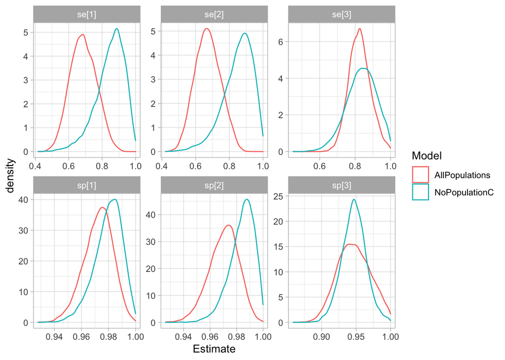

```r
all_mcmc <- combine.mcmc(results, vars="^s", return.samples = 10000)
noc_mcmc <- combine.mcmc(results_noC, vars="^s", return.samples = 10000)

bind_rows(
  as.data.frame(all_mcmc) %>% mutate(Model = "AllPopulations"),
  as.data.frame(noc_mcmc) %>% mutate(Model = "NoPopulationC")
) %>%
  pivot_longer(-Model, names_to = "Parameter", values_to = "Estimate") %>%
  ggplot() +
  aes(x = Estimate, col = Model) +
  geom_density() +
  facet_wrap( ~ Parameter, scales="free")
```

Removing the population C has affected the estimated sensitivity of the two capsid tests (compared to the impact of removing either population A or B, which I have not shown here!). Perhaps making blood smears directly from the carcasses recovers more intact capsids than making the smears from blood swabs?

## Summary

- Validation of model assumptions is essential but tricky
- Where we have 2 tests and 2 populations it is difficult to do anything other than biological justification
- Dropping one population/test at a time is a useful form of cross-validation if we have enough data
- Some further reading: Toft et al, STARD BLCM guidelines